# Projeto Diversidade de Plantas nas Dunas de Areia – Lake Michigan

# **Calcular indices de diversidade**

## **Calcular riqueza**

Com a tabela pronta, vamos calcular o riqueza de espécies a partir da tabela dune que é a composição de espécies. A riqueza é a contagem do número de espécies diferentes encontradas numa área definida, como um ecossistema ou uma região, sem considerar a quantidade de indivíduos de cada espécie.

```r
riqueza <- data.frame(specnumber(dune))
colnames(riqueza) <- "riqueza"
```

## **Calcular abundância**

Também vamos calcular a abundância de espécies a partir da tabela dune. A abundancia é o número total de indivíduos de uma determinada espécie num local específico.

```r
abundancia <- data.frame(rowSums(dune))
colnames(abundancia) <- "abundancia"
```

## **Indice de Shannon (H’)**

Vamos calcular o Indice de Shannon (H’). O Indice de Shannon mede a diversidade daquele ambiente. Assim, você sabera como uma comunidade de espécies, e considera tanto o número de espécies (riqueza) quanto a sua abundância relativa (uniformidade). Quanto maior o valor do índice H’, maior a diversidade, indicando mais espécies e/ou uma distribuição mais equitativa de indivíduos entre elas.

```r
shannon <- data.frame(round(diversity(dune, index = "shannon"), 3))
colnames(shannon) <- "shannon"
```

## **Indice de Simpson**

```r
simpson <- data.frame(round(diversity(dune, index = "simpson"), 3))
colnames(simpson) <- "simpson"
```

## **Indice de Pielou (J’)**

O índice de Pielou (J’) mede a uniformidade (ou equabilidade) da distribuição dos indivíduos entre as espécies numa comunidade ecológica, variando de 0 (mínima uniformidade) a 1 (máxima uniformidade). Um valor de J’ = 1 indica que todas as espécies têm o mesmo número de indivíduos, enquanto um valor próximo de 0 sinaliza que uma ou poucas espécies dominam a comunidade, com as demais sendo raras.

```r
pielou <- data.frame(round(shannon / log(riqueza), 3))
colnames(pielou) <- "pielou"
```

# **Estimadores de riqueza**

## **Chao, Jackknife1, Jackknife2 e Bootstrap**

Os estimadores de riqueza (Chao, Jackknife 1, Jackknife, Bootstrap) são métodos estatísticos utilizados em ecologia para estimar o número total de espécies numa área, indo além da riqueza observada na amostra e prevendo a quantidade de espécies que ainda podem ser descobertas. Os estimadores Jackknife e Bootstrap são técnicas de reamostragem que usam os dados da amostra para criar múltiplas amostras artificiais, permitindo calcular a variância e a precisão da estimativa da riqueza. O estimador Chao é um método estatístico que utiliza a abundância de espécies raras para estimar a riqueza total.

```r
chao1 <- estaccumR(dune, permutations = 100)
chao1 <- data.frame(chao1[["means"]])
chao1 <- data.frame(chao1[, 3])
colnames(chao1) <- "chao1"

estimadores <- poolaccum(dune, permutations = 100, minsize = 1)
```

## **Extrair os estimadores**

Para adicionar o resultado a uma data frame vamos extrair os estimadores.

```r
estimadores <- data.frame(estimadores[["means"]])
estimadores <- estimadores[, 3:6]
colnames(estimadores) <- c("chao2", "jack1", "jack2", "bootstrap")
```

# **Agrupar dados**

Com todos os dados calculados, vamos juntar tudos a uma data frame.

```r
dados <- data.frame(amostras   = seq_len(nrow(dune.env)),
                    dune.env,
                    riqueza,
                    abundancia,
                    shannon,
                    simpson,
                    pielou,
                    chao1,
                    estimadores,
                    dune)

# Conferir estrutura dos dados
str(dados)
```

```
## 'data.frame':    20 obs. of  46 variables:
##  $ amostras    : int  1 2 3 4 5 6 7 8 9 10 ...
##  $ Umidade_solo: num  2.8 3.5 4.3 4.2 6.3 4.3 2.8 4.2 3.7 3.3 ...
##  $ Umidade     : Ord.factor w/ 4 levels "1"<"2"<"4"<"5": 1 1 2 2 1 1 1 4 3 2 ...
##  $ Manejo      : Factor w/ 4 levels "Pasto_Baixo",..: 4 1 4 4 2 2 2 2 2 1 ...
##  $ Uso         : Ord.factor w/ 3 levels "Feno_Pastagem"<..: 2 2 2 2 1 2 3 3 1 1 ...
##  $ Esterco     : Ord.factor w/ 5 levels "0"<"1"<"2"<"3"<..: 5 3 5 5 3 3 4 4 2 2 ...
##  $ riqueza     : int  5 10 10 13 14 11 13 12 13 12 ...
##  $ abundancia  : num  18 42 40 45 43 48 40 40 42 43 ...
##  $ shannon     : num  1.44 2.25 2.19 2.43 2.54 ...
##  $ simpson     : num  0.735 0.89 0.879 0.901 0.914 0.9 0.907 0.909 0.912 0.903 ...
##  $ pielou      : num  0.895 0.978 0.953 0.946 0.964 0.978 0.964 0.98 0.972 0.965 ...
##  $ chao1       : num  9.8 14.9 18.5 21.1 23.1 ...
##  $ chao2       : num  9.73 25.52 26.26 28.85 28.82 ...
##  $ jack1       : num  9.73 19.87 24.51 27.7 29.21 ...
```

[output cut: 32 more lines]

```r
# Os dados já estão na estrutura desejada.
```

# **Análisar os dados exploratória**

Agora que temos nossos dados prontos, vamos analisar os dados com o objetivo de responder a nossa pergunta.

## **Média de Shannon, Simpson e Pielou**

Incialmente vamos visualizar o resultado da média dos indices de diversidade em uma tabela.

```r
library(dplyr)
library(knitr)

# Renomear as categorias sem underscores
dados$Uso <- recode(dados$Uso,
                     "Feno_Pastagem" = "Feno Pastagem",
                     "Feno" = "Feno",
                     "Pasto" = "Pasto")

dados$Manejo <- recode(dados$Manejo,
                        "Pasto_Baixo" = "Pasto Baixo",
                        "Pasto_Alto" = "Pasto Alto",
                        "Sem_Manejo" = "Sem Manejo",
                        "Pasto_Adubado" = "Pasto Adubado")

# Criar a tabela de médias por Uso e Manejo
media_diversidade_agrupada <- dados %>%
  group_by(Uso, Manejo) %>%
  summarise(
    Shannon = mean(shannon, na.rm = TRUE),
    Simpson = mean(simpson, na.rm = TRUE),
    Pielou  = mean(pielou, na.rm = TRUE),
    .groups = "drop"
  )

# Mostrar a tabela
kable(media_diversidade_agrupada, digits = 3, caption = "Média dos índices de diversidade por Uso e Manejo")
```

Média dos índices de diversidade por Uso e Manejo

| Uso | Manejo | Shannon | Simpson | Pielou |
| --- | --- | --- | --- | --- |
| Feno Pastagem | Pasto Baixo | 2.399 | 0.903 | 0.965 |
| Feno Pastagem | Pasto Alto | 2.519 | 0.913 | 0.968 |
| Feno Pastagem | Sem Manejo | 2.034 | 0.860 | 0.966 |
| Feno | Pasto Baixo | 2.253 | 0.890 | 0.978 |
| Feno | Pasto Alto | 2.346 | 0.900 | 0.978 |
| Feno | Sem Manejo | 1.979 | 0.851 | 0.952 |
| Feno | Pasto Adubado | 2.055 | 0.847 | 0.934 |
| Pasto | Pasto Baixo | 2.106 | 0.867 | 0.958 |
| Pasto | Pasto Alto | 2.454 | 0.908 | 0.972 |
| Pasto | Sem Manejo | 1.864 | 0.833 | 0.958 |
| Pasto | Pasto Adubado | 1.960 | 0.843 | 0.943 |

## **Riqueza observada e chao 1**

Vamos criar um gráfico com a riqueza observada e a riqueza estimada. Vamos utilizar o indice chao 1. Mas pode ser utilizado qualquer um dos inices calculados.

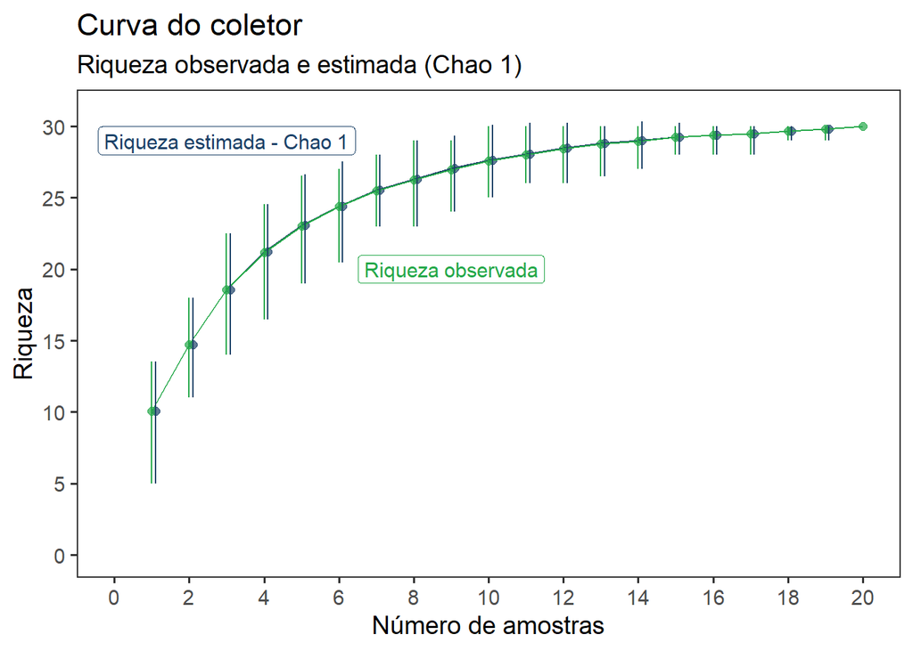

```r
# carregar pacote ggplot2

library(ggplot2)

# Estimador Chao1
chao1 <- estaccumR(dune, permutations = 100)

# Extrair resultados
resultados <- summary(chao1, display = c("S", "chao"))

# Criar data frame organizado
res_chao <- data.frame(
  amostras   = resultados$chao[, 1],
  chao       = resultados$chao[, 2],
  c_inferior = resultados$chao[, 3],
  c_superior = resultados$chao[, 4],
  riqueza    = resultados$S[, 2],
  r_inferior = resultados$S[, 3],
  r_superior = resultados$S[, 4]
)

# Gráfico
g_chao <- ggplot(res_chao) +
  aes(x = amostras) +
  geom_point(
    aes(y = chao, x = amostras + 0.1),
    size = 2, color = "#1c4268", alpha = 0.7
  ) +
  geom_point(
    aes(y = riqueza, x = amostras),
    size = 2, color = "#24a849", alpha = 0.7
  ) +
  geom_line(aes(y = chao, x = amostras), color = "#1c4268") +
  geom_line(aes(y = riqueza, x = amostras), color = "#24a849") +
  geom_linerange(aes(ymin = c_inferior, ymax = c_superior, x = amostras + 0.1),
                 color = "#1c4268") +
  geom_linerange(aes(ymin = r_inferior, ymax = r_superior, x = amostras),
                 color = "#24a849") +
  geom_label(
    y = 29, x = 3,
    label = "Riqueza estimada - Chao 1",
    size = 4, color = "#1c4268"
  ) +
  geom_label(
    y = 20, x = 9,
    label = "Riqueza observada",
    size = 4, color = "#24a849"
  ) +
  scale_y_continuous(breaks = seq(0, 31, 5),
                     limits = c(0, 31)) +
  scale_x_continuous(breaks = seq(0, 20, 2),
                     limits = c(0, 20)) +
  labs(
    x = "Número de amostras",
    y = "Riqueza",
    title = "Curva do coletor",
    subtitle = "Riqueza observada e estimada (Chao 1)"
  ) +
  theme_test(base_size = 14)

g_chao
```

## **Riqueza observada e jackknife**

Vamos criar um gráfico com a riqueza observada e a riqueza estimada. Agora vamos utilizar o indice jackknife. Mas pode ser utilizado qualquer um dos inices calculados.

```r
# Estimador Jackknife 1
jack1 <- poolaccum(dune, permutations = 100, minsize = 1)
summary(jack1, display = "jack1")
```

```
## $jack1
##        N Jackknife 1     2.5%    97.5%   Std.Dev
##  [1,]  1     9.64000  5.95000 14.00000 2.2271057
##  [2,]  2    20.20000 13.00000 27.00000 3.7043518
##  [3,]  3    24.97000 17.66667 33.50833 4.0847077
##  [4,]  4    27.69750 20.10625 33.50000 3.7175014
##  [5,]  5    29.76600 23.29500 35.50500 3.6051652
##  [6,]  6    30.85667 24.33333 37.00000 3.6146463
##  [7,]  7    31.80429 26.21071 37.36071 3.2495123
##  [8,]  8    32.10125 25.97500 37.62500 3.2055377
##  [9,]  9    32.13667 26.60833 37.89444 2.7545315
## [10,] 10    32.05700 26.28000 37.62000 2.6636064
## [11,] 11    32.30545 27.20227 36.36364 2.2879571
## [12,] 12    32.68500 28.30833 36.41667 2.1168377
## [13,] 13    32.69769 28.84615 36.46154 1.9790383
## [14,] 14    32.95429 29.29821 36.02143 1.7344152
## [15,] 15    32.82867 29.37667 35.60000 1.6794595
## [16,] 16    32.73625 29.87500 34.68750 1.3790854
## [17,] 17    32.67529 30.35735 34.70588 1.2440338
## [18,] 18    32.69389 30.88889 33.77778 0.9585985
## [19,] 19    32.69105 30.89474 33.78947 0.7836094
## [20,] 20    32.85000 32.85000 32.85000 0.0000000
##
## attr(,"class")
## [1] "summary.poolaccum"
```

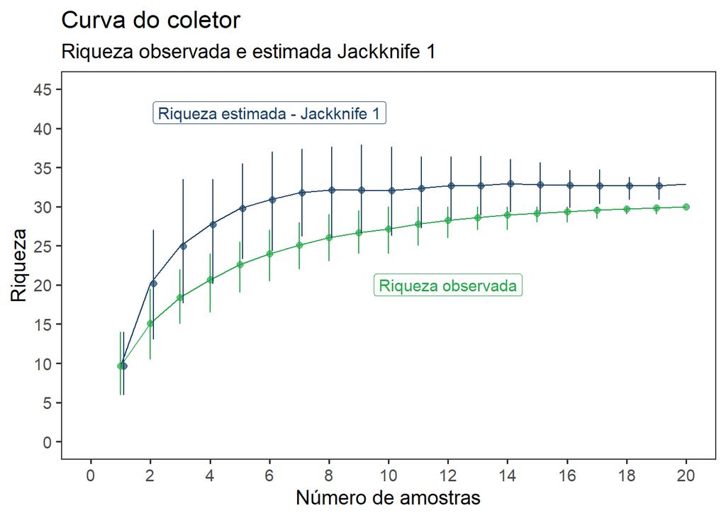

```r
# Extrair resultados
resultados_jack1 <- summary(jack1, display = c("S", "jack1"))

# Criar data frame organizado
res_jack1 <- data.frame(
  amostras   = resultados_jack1$jack1[, 1],
  jack1      = resultados_jack1$jack1[, 2],
  j_inferior = resultados_jack1$jack1[, 3],
  j_superior = resultados_jack1$jack1[, 4],
  riqueza    = resultados_jack1$S[, 2],
  r_inferior = resultados_jack1$S[, 3],
  r_superior = resultados_jack1$S[, 4]
)

# Gráfico
g_jack1 <- ggplot(res_jack1) +
  aes(x = amostras) +
  geom_point(
    aes(y = jack1, x = amostras + 0.1),
    size = 2, color = "#1c4268", alpha = 0.7
  ) +
  geom_point(
    aes(y = riqueza, x = amostras),
    size = 2, color = "#24a849", alpha = 0.7
  ) +
  geom_line(aes(y = jack1, x = amostras), color = "#1c4268") +
  geom_line(aes(y = riqueza, x = amostras), color = "#24a849") +
  geom_linerange(aes(ymin = j_inferior, ymax = j_superior, x = amostras + 0.1),
                 color = "#1c4268") +
  geom_linerange(aes(ymin = r_inferior, ymax = r_superior, x = amostras),
                 color = "#24a849") +
  geom_label(
    y = 42, x = 6,
    label = "Riqueza estimada - Jackknife 1",
    size = 4, color = "#1c4268"
  ) +
  geom_label(
    y = 20, x = 12,
    label = "Riqueza observada",
    size = 4, color = "#24a849"
  ) +
  scale_y_continuous(breaks = seq(0, 45, 5),
                     limits = c(0, 45)) +
  scale_x_continuous(breaks = seq(0, 20, 2),
                     limits = c(0, 20)) +
  labs(
    x = "Número de amostras",
    y = "Riqueza",
    title = "Curva do coletor",
    subtitle = "Riqueza observada e estimada Jackknife 1"
  ) +
  theme_test(base_size = 14)

g_jack1
```

# **Análise de dados**

## **GLMs para a variável riqueza**

Agora vamos testar a nossa hipótese usando um GLM. Como os nossos dados são de contagem, precisamos de um modelo com distribuição poisson.

```r
names(dados)
```

```
##  [1] "amostras"     "Umidade_solo" "Umidade"      "Manejo"       "Uso"
##  [6] "Esterco"      "riqueza"      "abundancia"   "shannon"      "simpson"
## [11] "pielou"       "chao1"        "chao2"        "jack1"        "jack2"
## [16] "bootstrap"    "Achimill"     "Agrostol"     "Airaprae"     "Alopgeni"
## [21] "Anthodor"     "Bellpere"     "Bromhord"     "Chenalbu"     "Cirsarve"
## [26] "Comapalu"     "Eleopalu"     "Elymrepe"     "Empenigr"     "Hyporadi"
## [31] "Juncarti"     "Juncbufo"     "Lolipere"     "Planlanc"     "Poaprat"
## [36] "Poatriv"      "Ranuflam"     "Rumeacet"     "Sagiproc"     "Salirepe"
## [41] "Scorautu"     "Trifprat"     "Trifrepe"     "Vicilath"     "Bracruta"
## [46] "Callcusp"
```

```r
modelo_poisson <- glm(riqueza ~ Umidade_solo + Umidade + Manejo + Uso + Esterco,family = poisson, data   = dados)

# Checar pressupostos
library(easystats)
library(performance)

check_overdispersion(modelo_poisson)
```

```
## # Overdispersion test
##
##        dispersion ratio = 0.546
##   Pearson's Chi-Squared = 3.273
##                 p-value = 0.774
```

```
## No overdispersion detected.
```

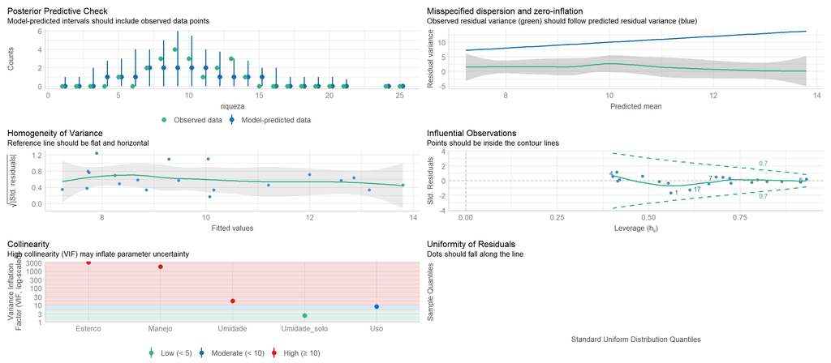

```r
check_model(modelo_poisson)
```

### **Corrigir superdispersão (Binomial Negativo)**

Caso haja, nesse caso não seria preciso, o modelo poisson, já está ajustado. Mas fizemos para demonstrar como fazer caso você precise.

```r
library(MASS)
modelo_nb <- glm.nb(riqueza ~ Umidade_solo + Umidade + Manejo + Uso + Esterco, data   = dados)

# Checar pressupostos do modelo
check_overdispersion(modelo_nb)
```

```
## # Overdispersion test
##
##  dispersion ratio =   0.158
##           p-value = < 0.001
```

```
## Underdispersion detected.
```

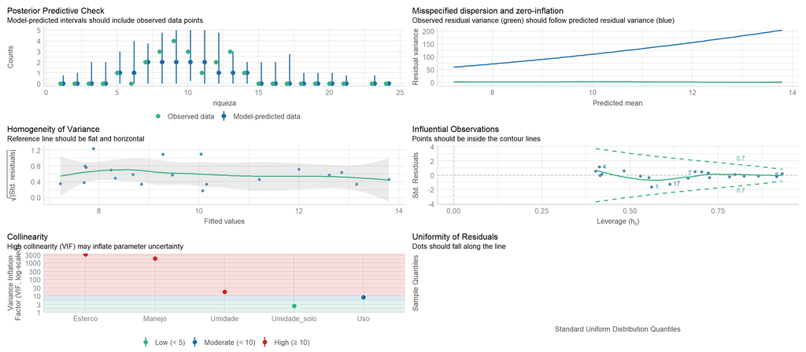

```r
check_model(modelo_nb)
```

### **Comparar modelos**

Uma forma de escolhe o melhor ajuste para o seu modelo é comparando os modelos. Aqui usamos a função compare_performance do pacote performance

```r
compare_performance(modelo_poisson, modelo_nb, rank = TRUE)
```

```
## Following indices with missing values are not used for ranking: Sigma
```

```
## # Comparison of Model Performance Indices
##
## Name           |  Model | Nagelkerke's R2 |  RMSE | Sigma | Score_log | Score_spherical | AIC weights | AICc weights | BIC weights | Performance-Score
## ------------------------------------------------------------------------------------------------------------------------------------------------------
## modelo_poisson |    glm |           0.762 | 1.211 | 1.000 |    -2.141 |           0.221 |       0.731 |        1.000 |       0.817 |           100.00%
## modelo_nb      | negbin |           0.762 | 1.211 | 1.000 |    -3.088 |           0.218 |       0.269 |     3.15e-06 |       0.183 |             0.00%
```

** Modelo poisson é o melhor modelo**

### **Resultado**

```r
resultado_riqueza<-anova(modelo_poisson, test = "Chi")
```

## **Criar GLMs abundância**

Assim como fizemos para riqueza vamos repetir para abundância.

```r
names(dados)
```

```
##  [1] "amostras"     "Umidade_solo" "Umidade"      "Manejo"       "Uso"
##  [6] "Esterco"      "riqueza"      "abundancia"   "shannon"      "simpson"
## [11] "pielou"       "chao1"        "chao2"        "jack1"        "jack2"
## [16] "bootstrap"    "Achimill"     "Agrostol"     "Airaprae"     "Alopgeni"
## [21] "Anthodor"     "Bellpere"     "Bromhord"     "Chenalbu"     "Cirsarve"
## [26] "Comapalu"     "Eleopalu"     "Elymrepe"     "Empenigr"     "Hyporadi"
## [31] "Juncarti"     "Juncbufo"     "Lolipere"     "Planlanc"     "Poaprat"
## [36] "Poatriv"      "Ranuflam"     "Rumeacet"     "Sagiproc"     "Salirepe"
## [41] "Scorautu"     "Trifprat"     "Trifrepe"     "Vicilath"     "Bracruta"
## [46] "Callcusp"
```

```r
modelo_poisson_abu <- glm(abundancia ~ Umidade_solo + Umidade + Manejo + Uso + Esterco,family = poisson, data   = dados)

# Checar pressupostos
library(easystats)
library(performance)

check_overdispersion(modelo_poisson_abu)
```

```
## # Overdispersion test
##
##        dispersion ratio =  2.663
##   Pearson's Chi-Squared = 15.978
##                 p-value =  0.014
```

```
## Overdispersion detected.
```

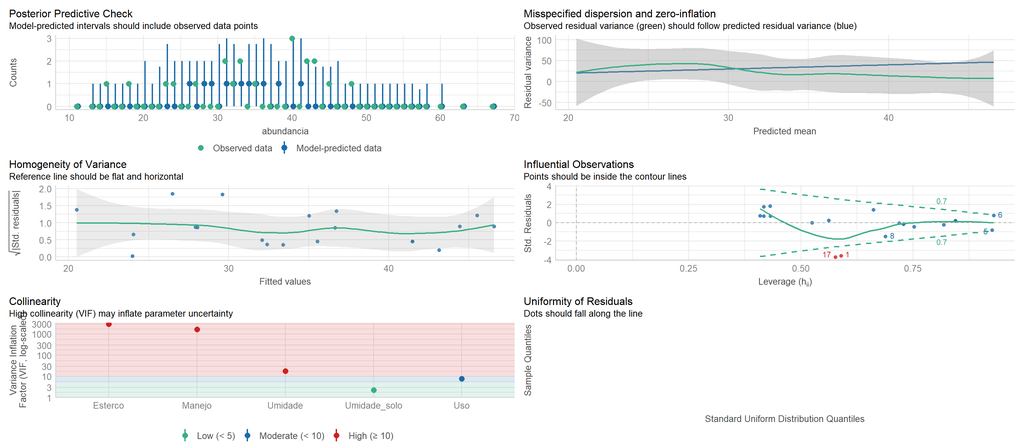

```r
check_model(modelo_poisson_abu)
```

### **Corrigir superdispersão (Binomial Negativo)**

```r
library(MASS)
modelo_nb_abu <- glm.nb(abundancia ~ Umidade_solo + Umidade + Manejo + Uso + Esterco, data   = dados)

# Checar pressupostos
check_overdispersion(modelo_nb_abu)
```

```
## # Overdispersion test
##
##  dispersion ratio = 0.719
##           p-value = 0.408
```

```
## No overdispersion detected.
```

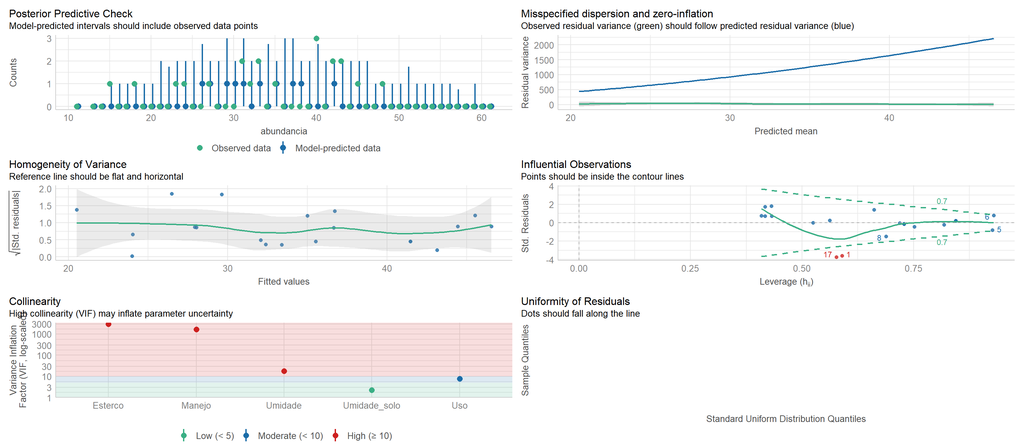

```r
check_model(modelo_nb_abu)
```

### **Comparar modelos**

```r
compare_performance(modelo_poisson_abu, modelo_nb_abu, rank = TRUE)
```

```
## Following indices with missing values are not used for ranking: Sigma
```

```
## # Comparison of Model Performance Indices
##
## Name               |  Model | Nagelkerke's R2 |  RMSE | Sigma | Score_log | Score_spherical | AIC weights | AICc weights | BIC weights | Performance-Score
## ----------------------------------------------------------------------------------------------------------------------------------------------------------
## modelo_poisson_abu |    glm |           0.886 | 4.844 | 1.000 |    -3.100 |           0.208 |       0.731 |        1.000 |       0.817 |            85.71%
## modelo_nb_abu      | negbin |           0.886 | 4.844 | 1.000 |    -3.532 |           0.219 |       0.269 |     3.15e-06 |       0.183 |            14.29%
```

### **Modelo poisson é melhor**

```r
resultado_abundancia<-anova(modelo_poisson_abu, test = "Chi")
```

### **Análise de contraste**

Quando trabalhamos com variáveis categóricas que possuem **mais de dois níveis**, o teste realizado apenas informa se existem diferenças significativas entre os grupos de forma geral. No entanto, ele **não indica entre quais pares de grupos** essas diferenças ocorrem. Por isso, é necessário realizar um **pós-teste de contraste**, que compara os grupos **par a par**. Dessa forma, conseguimos identificar exatamente **onde estão as diferenças significativas** entre os níveis da variável analisada.

```r
library(emmeans)
library(multcomp)
library(multcompView)

modelo_abu <- glm(abundancia ~Manejo,family = poisson, data   = dados)
pos_teste = emmeans(modelo_abu,
                    ~Manejo)

pos_teste
```

```
##  Manejo        emmean     SE  df asymp.LCL asymp.UCL
##  Pasto Baixo     3.66 0.0925 Inf      3.48      3.84
##  Pasto Alto      3.75 0.0685 Inf      3.62      3.89
##  Sem Manejo      3.23 0.0814 Inf      3.07      3.39
##  Pasto Adubado   3.53 0.0700 Inf      3.39      3.66
##
## Results are given on the log (not the response) scale.
## Confidence level used: 0.95
```

```r
pairs(pos_teste,
      adjust="sidak")
```

```
##  contrast                    estimate    SE  df z.ratio p.value
##  Pasto Baixo - Pasto Alto     -0.0883 0.115 Inf  -0.767  0.9701
##  Pasto Baixo - Sem Manejo      0.4380 0.123 Inf   3.557  0.0023
##  Pasto Baixo - Pasto Adubado   0.1372 0.116 Inf   1.183  0.8023
##  Pasto Alto - Sem Manejo       0.5263 0.106 Inf   4.948  <.0001
##  Pasto Alto - Pasto Adubado    0.2255 0.098 Inf   2.302  0.1214
##  Sem Manejo - Pasto Adubado   -0.3008 0.107 Inf  -2.802  0.0301
##
## Results are given on the log (not the response) scale.
## P value adjustment: sidak method for 6 tests
```

```r
# Separando os grupos

cld(pos_teste,
    alpha=0.05,
    Letters=letters,
    adjust="sidak")
```

```
##  Manejo        emmean     SE  df asymp.LCL asymp.UCL .group
##  Sem Manejo      3.23 0.0814 Inf      3.02      3.43  a
##  Pasto Adubado   3.53 0.0700 Inf      3.35      3.70   b
##  Pasto Baixo     3.66 0.0925 Inf      3.43      3.89   b
##  Pasto Alto      3.75 0.0685 Inf      3.58      3.92   b
##
## Results are given on the log (not the response) scale.
## Confidence level used: 0.95
## Conf-level adjustment: sidak method for 4 estimates
## P value adjustment: sidak method for 6 tests
## significance level used: alpha = 0.05
## NOTE: If two or more means share the same grouping symbol,
##       then we cannot show them to be different.
##       But we also did not show them to be the same.
```

### **Tabela com o resultado do GLM**

Criamos uma tabela para apresentar o resulto da nossa análise.

```r
# Renomear as categorias sem underscores
dados$Uso <- recode(dados$Uso,
                     "Feno_Pastagem" = "Feno Pastagem",
                     "Feno" = "Feno",
                     "Pasto" = "Pasto")

dados$Manejo <- recode(dados$Manejo,
                        "Pasto_Baixo" = "Pasto Baixo",
                        "Pasto_Alto" = "Pasto Alto",
                        "Sem_Manejo" = "Sem Manejo",
                        "Pasto_Adubado" = "Pasto Adubado")
# Tabela riqueza
tabela_riqueza <- data.frame(
  Variavel_Resposta    = "Riqueza",
  Variavel_Explicativa = rownames(resultado_riqueza),
  Distribuicao         = "Poisson",
  Df                   = resultado_riqueza$Df,
  Deviance             = resultado_riqueza$Deviance,
  Pvalor               = resultado_riqueza$`Pr(>Chi)`
) %>%
  filter(!Variavel_Explicativa %in% "NULL") %>%
  rename(
    "Variavel Resposta"    = Variavel_Resposta,
    "Variavel Explicativa" = Variavel_Explicativa,
    "Distribuicao"         = Distribuicao,
    "Df"                   = Df,
    "Deviance"             = Deviance,
    "P-valor"              = Pvalor
  )

# Tabela abundância
tabela_abundancia <- data.frame(
  Variavel_Resposta    = "Abundancia",
  Variavel_Explicativa = rownames(resultado_abundancia),
  Distribuicao         = "Poisson",
  Df                   = resultado_abundancia$Df,
  Deviance             = resultado_abundancia$Deviance,
  Pvalor               = resultado_abundancia$`Pr(>Chi)`
) %>%
  filter(!Variavel_Explicativa %in% "NULL") %>%
  rename(
    "Variavel Resposta"    = Variavel_Resposta,
    "Variavel Explicativa" = Variavel_Explicativa,
    "Distribuicao"         = Distribuicao,
    "Df"                   = Df,
    "Deviance"             = Deviance,
    "P-valor"              = Pvalor
  )
# Combinar as duas tabelas
tabela_completa <- bind_rows(tabela_riqueza, tabela_abundancia)

# Mostrar tabela final
kable(tabela_completa, digits = 4, caption = "Tabela 1: Resutado dos modelos para riqueza e abundancia")
```

Tabela 1: Resutado dos modelos para riqueza e abundancia

| Variavel Resposta | Variavel Explicativa | Distribuicao | Df | Deviance | P-valor |
| --- | --- | --- | --- | --- | --- |
| Riqueza | Umidade_solo | Poisson | 1 | 0.5503 | 0.4582 |
| Riqueza | Umidade | Poisson | 3 | 0.7542 | 0.8604 |
| Riqueza | Manejo | Poisson | 3 | 6.1191 | 0.1060 |
| Riqueza | Uso | Poisson | 2 | 0.3505 | 0.8392 |
| Riqueza | Esterco | Poisson | 3 | 0.3113 | 0.9579 |
| Abundancia | Umidade_solo | Poisson | 1 | 4.3509 | 0.0370 |
| Abundancia | Umidade | Poisson | 3 | 1.8733 | 0.5991 |
| Abundancia | Manejo | Poisson | 3 | 23.3199 | 0.0000 |
| Abundancia | Uso | Poisson | 2 | 2.2920 | 0.3179 |
| Abundancia | Esterco | Poisson | 3 | 2.2052 | 0.5309 |

# **Visualização gráfica**

Agora que fizemos todas as análises vamos criar os gráficos apenas dos resultados estatisticamente signficativo.

## **Gráfico da variável Umidade do solo**

```r
library(ggplot2)
names(dados)
```

```
##  [1] "amostras"     "Umidade_solo" "Umidade"      "Manejo"       "Uso"
##  [6] "Esterco"      "riqueza"      "abundancia"   "shannon"      "simpson"
## [11] "pielou"       "chao1"        "chao2"        "jack1"        "jack2"
## [16] "bootstrap"    "Achimill"     "Agrostol"     "Airaprae"     "Alopgeni"
## [21] "Anthodor"     "Bellpere"     "Bromhord"     "Chenalbu"     "Cirsarve"
## [26] "Comapalu"     "Eleopalu"     "Elymrepe"     "Empenigr"     "Hyporadi"
## [31] "Juncarti"     "Juncbufo"     "Lolipere"     "Planlanc"     "Poaprat"
## [36] "Poatriv"      "Ranuflam"     "Rumeacet"     "Sagiproc"     "Salirepe"
## [41] "Scorautu"     "Trifprat"     "Trifrepe"     "Vicilath"     "Bracruta"
## [46] "Callcusp"
```

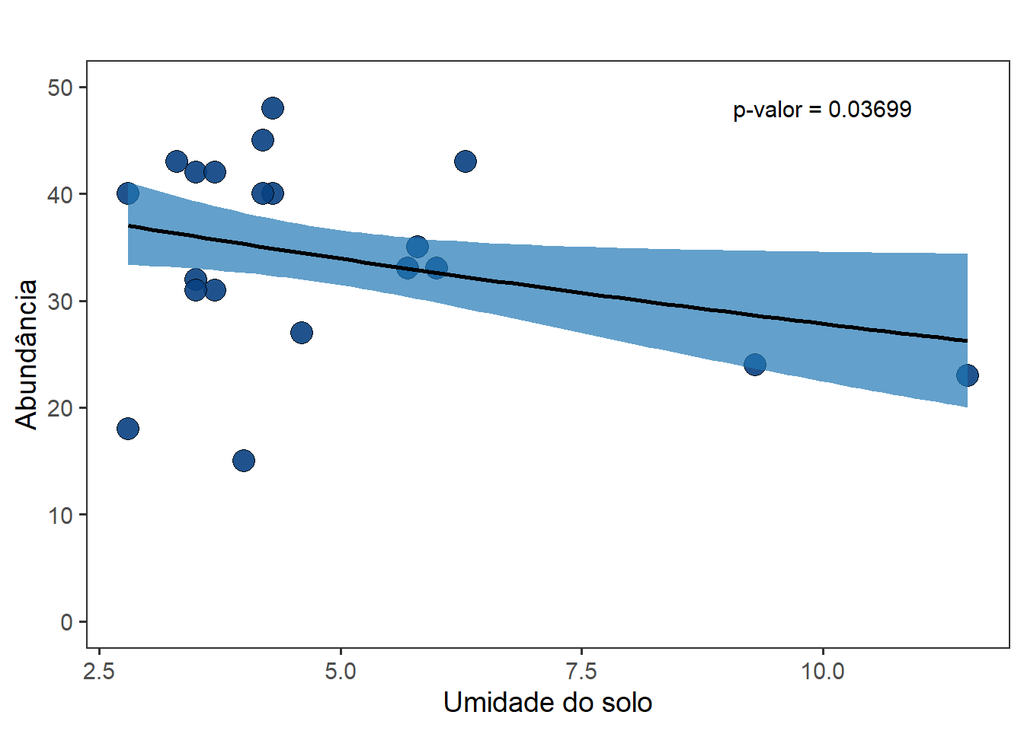

```r
g1<-ggplot(dados) +
  aes(x = Umidade_solo,
      y = abundancia) +
  geom_point(shape = 21,
             size = 5,
             fill = "#084081",
             color = "#000000",
             alpha=0.9) +
  geom_smooth(formula = y ~ x,
              method = "glm",
              method.args = list(family = "poisson"),
              se = TRUE,
              color = "#000000",
              fill = "#1f77b4",
              alpha = 0.7) +
  scale_y_continuous(limits = c(0,50),
                     breaks = seq(0,50,10)) +
  labs(x = "Umidade do solo",
       y = "Abundância",
       title = "") +
  theme_test(base_size = 14) +
  theme(legend.position = "none") +
  annotate(
    "text",
    x = 10,
    y = 48,
    size = 4,
    color = "#000000",
    label = "p-valor = 0.03699")
g1
```

## **Gráfico da variável Manejo**

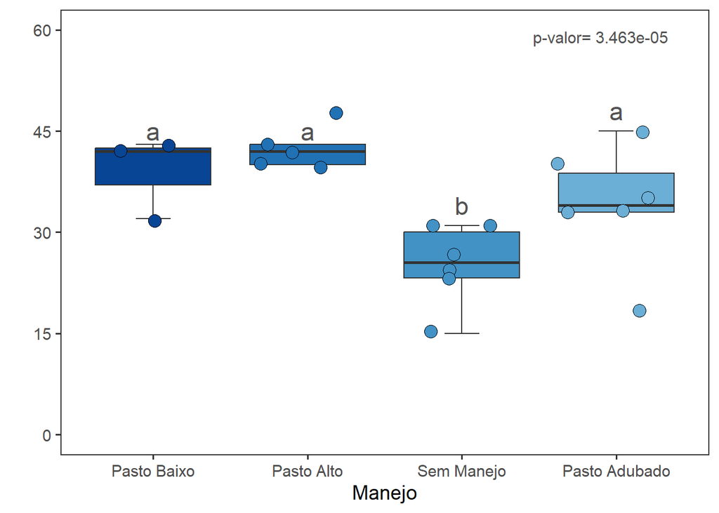

```r
g2 <- ggplot(dados) +
  aes(x = Manejo,
      y = abundancia,
      fill = Manejo) +
  geom_boxplot(outlier.shape = NA,
               staplewidth = 0.3) +
  geom_jitter(shape = 21,
              size = 4) +
  scale_fill_manual(name = "Manejo",
                    values = c("#084594",
                               "#2171b5",
                               "#4292c6",
                               "#6baed6"))+
  scale_y_continuous(limits = c(0, 60),
                      breaks = seq(0, 95, 15)) +
  scale_x_discrete(labels = c("Pasto Baixo",
                              "Pasto Alto",
                              "Sem Manejo",
                              "Pasto Adubado")) +
  labs(x = "Manejo",
       y = "") +
  theme_test(base_size = 14) +
  theme(legend.position = "none") +
  annotate(
    "text",
    x = 3.9,
    y = 59,
    size = 4,
    color = "#525252",
    label = "p-valor= 3.463e-05")+
  annotate(
    "text",
    x = 1,
    y = 45,
    size = 6,
    color = "#525252",
    label = "a"
  )+
   annotate(
    "text",
    x = 2,
    y = 45,
    size = 6,
    color = "#525252",
    label = "a"
  )+
  annotate(
    "text",
    x = 3,
    y = 34,
    size = 6,
    color = "#525252",
    label = "b"
  )+
  annotate(
    "text",
    x = 4,
    y = 48,
    size = 6,
    color = "#525252",
    label = "a"
  )

g2
```

### **Criando uma prancha**

Por fim, criamos uma prancha com os dois gráficos.

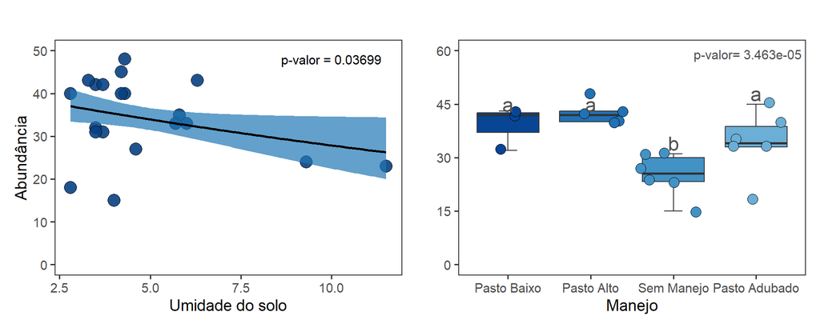

```r
library(patchwork)
g1+g2
```